# Marginal Structural Models for ART and Mortality

Hajin Jang

3/31/2025

###This code estimates the causal effect of sustained antiretroviral therapy initiation on mortality using marginal structural models with inverse probability weighting to address time-varying confounding and informative censoring.

## Estimating the hazard ratio with pooled logistic regression

```r
mod1 <- glm(death ~ art + month + monthsq,
    family = binomial(), data = dat)
summary(mod1)
```

```
##
## Call:
## glm(formula = death ~ art + month + monthsq, family = binomial(),
##     data = dat)
##
## Coefficients:
##               Estimate Std. Error z value Pr(>|z|)
## (Intercept) -7.536e+00  2.314e-01 -32.567   <2e-16 ***
## art          1.263e-01  1.947e-01   0.649    0.517
## month       -1.718e-02  2.016e-02  -0.852    0.394
## monthsq      5.913e-05  3.450e-04   0.171    0.864
## ---
## Signif. codes:  0 '***' 0.001 '**' 0.01 '*' 0.05 '.' 0.1 ' ' 1
##
## (Dispersion parameter for binomial family taken to be 1)
##
##     Null deviance: 2148.6  on 319517  degrees of freedom
## Residual deviance: 2142.5  on 319514  degrees of freedom
##   (452 observations deleted due to missingness)
## AIC: 2150.5
##
## Number of Fisher Scoring iterations: 11
```

```r
exp(coef(mod1)['art'])
```

```
##     art
## 1.13458
```

```r
mod2 <- glm(death ~ art + month + monthsq
    + factor(age_0_cat) + sex + factor(origin) + factor(mode)
    + factor(year_0_cat) + factor(cd4_0_cat) + factor(rna_0_cat),
    family = binomial(), data = dat)
summary(mod2)
```

```
##
## Call:
## glm(formula = death ~ art + month + monthsq + factor(age_0_cat) +
##     sex + factor(origin) + factor(mode) + factor(year_0_cat) +
##     factor(cd4_0_cat) + factor(rna_0_cat), family = binomial(),
##     data = dat)
##
## Coefficients:
##                       Estimate Std. Error z value Pr(>|z|)
## (Intercept)         -7.127e+00  5.456e-01 -13.062  < 2e-16 ***
## art                 -2.280e-01  2.122e-01  -1.074 0.282822
## month               -9.997e-03  2.017e-02  -0.496 0.620149
## monthsq             -3.631e-06  3.450e-04  -0.011 0.991602
## factor(age_0_cat)2   7.424e-01  2.235e-01   3.322 0.000895 ***
## factor(age_0_cat)3   1.779e+00  2.496e-01   7.126 1.04e-12 ***
## sex                 -4.833e-01  3.774e-01  -1.281 0.200296
## factor(origin)2      1.227e-02  4.862e-01   0.025 0.979873
## factor(origin)3     -2.210e-01  3.606e-01  -0.613 0.540000
## factor(origin)4     -2.322e-01  2.379e-01  -0.976 0.329106
## factor(mode)3        1.060e+00  4.088e-01   2.593 0.009520 **
## factor(mode)4       -1.104e-01  2.816e-01  -0.392 0.695111
## factor(year_0_cat)2 -8.466e-01  4.994e-01  -1.695 0.090072 .
## factor(year_0_cat)3 -9.836e-02  3.305e-01  -0.298 0.765982
## factor(year_0_cat)4 -7.614e-01  2.760e-01  -2.759 0.005803 **
## factor(cd4_0_cat)2  -3.253e-01  4.053e-01  -0.803 0.422230
## factor(cd4_0_cat)3  -7.584e-01  3.549e-01  -2.137 0.032594 *
## factor(cd4_0_cat)4  -6.306e-01  3.493e-01  -1.805 0.071012 .
## factor(cd4_0_cat)5  -8.690e-01  3.543e-01  -2.452 0.014190 *
## factor(rna_0_cat)2   4.717e-01  2.567e-01   1.837 0.066167 .
## factor(rna_0_cat)3   5.820e-01  2.728e-01   2.134 0.032869 *
## ---
## Signif. codes:  0 '***' 0.001 '**' 0.01 '*' 0.05 '.' 0.1 ' ' 1
##
## (Dispersion parameter for binomial family taken to be 1)
##
##     Null deviance: 2148.6  on 319517  degrees of freedom
## Residual deviance: 2058.9  on 319497  degrees of freedom
##   (452 observations deleted due to missingness)
## AIC: 2100.9
##
## Number of Fisher Scoring iterations: 11
```

```r
exp(coef(mod2)['art'])
```

```
##     art
## 0.79616
```

```r
mod3 <- glm(death ~ art + month + monthsq
    + factor(age_0_cat) + sex + factor(origin) + factor(mode)
    + factor(year_0_cat) + factor(cd4_0_cat) + factor(rna_0_cat)
    + cd4_v + cd4_v_sq + factor(rna_v_cat) + aids,
    family = binomial(), data = dat)
summary(mod3)
```

```
##
## Call:
## glm(formula = death ~ art + month + monthsq + factor(age_0_cat) +
##     sex + factor(origin) + factor(mode) + factor(year_0_cat) +
##     factor(cd4_0_cat) + factor(rna_0_cat) + cd4_v + cd4_v_sq +
##     factor(rna_v_cat) + aids, family = binomial(), data = dat)
##
## Coefficients:
##                       Estimate Std. Error z value Pr(>|z|)
## (Intercept)         -6.467e+00  5.783e-01 -11.183  < 2e-16 ***
## art                 -2.516e-01  2.260e-01  -1.113  0.26562
## month               -5.367e-03  2.049e-02  -0.262  0.79341
## monthsq             -5.152e-05  3.481e-04  -0.148  0.88233
## factor(age_0_cat)2   7.043e-01  2.239e-01   3.145  0.00166 **
## factor(age_0_cat)3   1.743e+00  2.495e-01   6.985 2.84e-12 ***
## sex                 -4.802e-01  3.787e-01  -1.268  0.20483
## factor(origin)2     -9.116e-02  4.862e-01  -0.187  0.85129
## factor(origin)3     -3.038e-01  3.629e-01  -0.837  0.40256
## factor(origin)4     -3.106e-01  2.422e-01  -1.283  0.19960
## factor(mode)3        9.628e-01  4.080e-01   2.360  0.01829 *
## factor(mode)4       -7.441e-02  2.829e-01  -0.263  0.79248
## factor(year_0_cat)2 -8.399e-01  4.999e-01  -1.680  0.09294 .
## factor(year_0_cat)3 -5.159e-02  3.321e-01  -0.155  0.87654
## factor(year_0_cat)4 -6.929e-01  2.798e-01  -2.477  0.01326 *
## factor(cd4_0_cat)2   5.041e-02  4.126e-01   0.122  0.90277
## factor(cd4_0_cat)3  -8.344e-02  3.789e-01  -0.220  0.82569
## factor(cd4_0_cat)4   1.981e-01  3.860e-01   0.513  0.60780
## factor(cd4_0_cat)5   1.438e-01  4.105e-01   0.350  0.72618
## factor(rna_0_cat)2   4.615e-01  2.614e-01   1.766  0.07748 .
## factor(rna_0_cat)3   5.402e-01  2.828e-01   1.910  0.05609 .
## cd4_v               -4.915e-03  9.669e-04  -5.084 3.70e-07 ***
## cd4_v_sq             2.577e-06  5.351e-07   4.816 1.47e-06 ***
## factor(rna_v_cat)2  -1.805e-01  2.632e-01  -0.686  0.49278
## factor(rna_v_cat)3   3.473e-01  3.047e-01   1.140  0.25432
## aids                 8.559e-01  3.448e-01   2.482  0.01306 *
## ---
## Signif. codes:  0 '***' 0.001 '**' 0.01 '*' 0.05 '.' 0.1 ' ' 1
##
## (Dispersion parameter for binomial family taken to be 1)
##
##     Null deviance: 2148.6  on 319517  degrees of freedom
## Residual deviance: 2021.3  on 319492  degrees of freedom
##   (452 observations deleted due to missingness)
## AIC: 2073.3
##
## Number of Fisher Scoring iterations: 11
```

```r
exp(coef(mod3)['art'])
```

```
##       art
## 0.7775324
```

**Comment:** These pooled logistic models approximate a discrete-time hazard model for death using month and month squared to capture baseline hazard shape. Across models with increasing covariate adjustment (unadjusted, baseline-adjusted, then baseline plus time-updated covariates), the estimated ART effect reflects associations that may still be biased by time-varying confounding affected by prior treatment, motivating the weighted MSM approach.

## Estimating components of the stabilized inverse probability treatment weights

```r
mod <- glm(art ~ month
  + factor(age_0_cat) + sex + factor(origin) + factor(mode)
  + factor(year_0_cat) + factor(cd4_0_cat) + factor(rna_0_cat)
    + cd4_v + cd4_v_sq + factor(rna_v_cat) + aids,
    family = binomial(), data = subset(dat,pastart==0))

dat$probA.d <- ifelse(dat$pastart==1,1,
    predict(mod, type = 'response'))

mod <- glm(art ~ month
  + factor(age_0_cat) + sex + factor(origin) + factor(mode)
  + factor(year_0_cat) + factor(cd4_0_cat) + factor(rna_0_cat),
    family = binomial(), data = subset(dat,pastart==0))
dat$probA.n <- ifelse(dat$pastart==1,1,
    predict(mod, type = 'response'))
```

**Comment:** These models estimate components of stabilized inverse probability treatment weights among those not yet treated (pastart=0). The denominator model includes baseline and time-updated predictors of ART initiation, while the numerator model uses baseline predictors only, aiming to balance time-varying confounding while preserving baseline structure in stabilized weights.

## Estimating components of the stabilized inverse probability censoring weights

```r
dat$notcensor <- 1- dat$censor

mod <- glm(notcensor ~ art + month + monthsq
  + factor(age_0_cat) + sex + factor(origin) + factor(mode)
  + factor(year_0_cat) + factor(cd4_0_cat) + factor(rna_0_cat)
    + cd4_v + cd4_v_sq + factor(rna_v_cat) + aids,
    family = binomial(), data = dat)
dat$probC.d <- predict(mod, type = 'response')


mod <- glm(notcensor ~ art + month + monthsq
  + factor(age_0_cat) + sex + factor(origin) + factor(mode)
  + factor(year_0_cat) + factor(cd4_0_cat) + factor(rna_0_cat),
    family = binomial(), data = dat)
dat$probC.n <- predict(mod, type = 'response')
```

**Comment:** These models estimate stabilized inverse probability censoring weights using notcensor as the outcome. The denominator allows censoring to depend on treatment and time-updated health status, while the numerator uses baseline covariates only, reducing bias from informative censoring under the assumption that included covariates sufficiently explain censoring.

## Estimating weights

```r
dat$A.num <- ifelse(dat$art==1,dat$probA.n,1-dat$probA.n)
dat$A.den <- ifelse(dat$art==1,dat$probA.d,1-dat$probA.d)
dat$A.numcum <- ave(dat$A.num,dat$id,
    FUN=function(x) cumprod(x))
dat$A.dencum <- ave(dat$A.den,dat$id,
    FUN=function(x) cumprod(x))


dat$swA <- dat$A.numcum/dat$A.dencum
dat$wA <- 1/dat$A.dencum


dat$C.numcum <- ave(dat$probC.n,dat$id,
    FUN=function(x) cumprod(x))
dat$C.dencum <- ave(dat$probC.d,dat$id,
    FUN=function(x) cumprod(x))
dat$swC <- dat$C.numcum/dat$C.dencum
dat$wC <- 1/dat$C.dencum

dat$sw <- dat$swA*dat$swC
dat$w <- dat$wA*dat$wC

summary(dat[,c('swA','wA','swC','wC','sw','w')])
```

```
##       swA                  wA                swC               wC
##  Min.   :  0.02044   Min.   :   1.001   Min.   :0.9443   Min.   :1.000
##  1st Qu.:  0.83548   1st Qu.:   1.401   1st Qu.:0.9976   1st Qu.:1.015
##  Median :  1.02680   Median :   9.504   Median :0.9999   Median :1.035
##  Mean   :  1.71052   Mean   :  94.700   Mean   :1.0000   Mean   :1.043
##  3rd Qu.:  1.71884   3rd Qu.:  90.616   3rd Qu.:1.0018   3rd Qu.:1.063
##  Max.   :102.69790   Max.   :7299.992   Max.   :1.0791   Max.   :1.435
##        sw                  w
##  Min.   :  0.02045   Min.   :   1.001
##  1st Qu.:  0.83498   1st Qu.:   1.461
##  Median :  1.02617   Median :  10.244
##  Mean   :  1.71140   Mean   :  99.634
##  3rd Qu.:  1.71768   3rd Qu.:  95.067
##  Max.   :102.11680   Max.   :8686.977
```

```r
dat$sw.trunc <- ifelse(dat$sw>10,10,dat$sw)
```

**Comment:** This chunk combines treatment and censoring components into final stabilized weights and summarizes their distribution to check positivity and identify extreme values. Weights are truncated at 10 to limit undue influence from highly weighted observations and improve estimator stability.

## Estimating the hazard ratio with inverse probability weighted pooled logistic regression

```r
modw.temp <- glm(death ~ art + month + monthsq
  + factor(age_0_cat) + sex + factor(origin) + factor(mode)
  + factor(year_0_cat) + factor(cd4_0_cat) + factor(rna_0_cat),
    family = quasibinomial(), data = dat, weights = sw.trunc)
summary(modw.temp)
```

```
##
## Call:
## glm(formula = death ~ art + month + monthsq + factor(age_0_cat) +
##     sex + factor(origin) + factor(mode) + factor(year_0_cat) +
##     factor(cd4_0_cat) + factor(rna_0_cat), family = quasibinomial(),
##     data = dat, weights = sw.trunc)
##
## Coefficients:
##                       Estimate Std. Error t value Pr(>|t|)
## (Intercept)         -7.2804455  0.5974815 -12.185  < 2e-16 ***
## art                 -0.3674087  0.2220733  -1.654  0.09804 .
## month               -0.0402063  0.0205893  -1.953  0.05085 .
## monthsq              0.0004507  0.0003463   1.302  0.19305
## factor(age_0_cat)2   0.7786810  0.2425352   3.211  0.00132 **
## factor(age_0_cat)3   1.9043276  0.2574786   7.396 1.41e-13 ***
## sex                 -0.7526761  0.4451447  -1.691  0.09087 .
## factor(origin)2      0.4268218  0.4259702   1.002  0.31634
## factor(origin)3     -0.8812260  0.5000494  -1.762  0.07802 .
## factor(origin)4     -0.5332519  0.2553967  -2.088  0.03680 *
## factor(mode)3        1.1714025  0.4842423   2.419  0.01556 *
## factor(mode)4        0.2332410  0.3046168   0.766  0.44386
## factor(year_0_cat)2 -0.1329905  0.4365865  -0.305  0.76066
## factor(year_0_cat)3  0.0270804  0.3637880   0.074  0.94066
## factor(year_0_cat)4 -0.6918831  0.3024530  -2.288  0.02216 *
## factor(cd4_0_cat)2   0.3716819  0.3680958   1.010  0.31262
## factor(cd4_0_cat)3  -0.7557601  0.3746081  -2.017  0.04365 *
## factor(cd4_0_cat)4  -0.3581425  0.3564022  -1.005  0.31495
## factor(cd4_0_cat)5  -0.6748979  0.3714561  -1.817  0.06923 .
## factor(rna_0_cat)2   0.5952641  0.2946513   2.020  0.04336 *
## factor(rna_0_cat)3   0.8247603  0.3006063   2.744  0.00608 **
## ---
## Signif. codes:  0 '***' 0.001 '**' 0.01 '*' 0.05 '.' 0.1 ' ' 1
##
## (Dispersion parameter for quasibinomial family taken to be 1.951478)
##
##     Null deviance: 3935.9  on 319517  degrees of freedom
## Residual deviance: 3685.8  on 319497  degrees of freedom
##   (452 observations deleted due to missingness)
## AIC: NA
##
## Number of Fisher Scoring iterations: 11
```

```r
exp(coef(modw.temp)['art'])
```

```
##       art
## 0.6925265
```

```r
require(geepack)
modw <- geeglm(death ~ art + month + monthsq
  + factor(age_0_cat) + sex + factor(origin) + factor(mode)
  + factor(year_0_cat) + factor(cd4_0_cat) + factor(rna_0_cat),
  data=dat,
  weights= sw.trunc,
  id= id,
  corstr='independence',
  family=binomial(link = "logit")) ##use geeglm for robust variance
summary(modw)
```

```
##
## Call:
## geeglm(formula = death ~ art + month + monthsq + factor(age_0_cat) +
##     sex + factor(origin) + factor(mode) + factor(year_0_cat) +
##     factor(cd4_0_cat) + factor(rna_0_cat), family = binomial(link = "logit"),
##     data = dat, weights = sw.trunc, id = id, corstr = "independence")
##
##  Coefficients:
##                       Estimate    Std.err    Wald Pr(>|W|)
## (Intercept)         -7.2804455  0.7040218 106.941  < 2e-16 ***
## art                 -0.3674087  0.3598417   1.042   0.3072
## month               -0.0402063  0.0361065   1.240   0.2655
## monthsq              0.0004507  0.0006060   0.553   0.4570
## factor(age_0_cat)2   0.7786810  0.3715640   4.392   0.0361 *
## factor(age_0_cat)3   1.9043276  0.3742296  25.894 3.61e-07 ***
## sex                 -0.7526761  0.6304262   1.425   0.2325
## factor(origin)2      0.4268218  0.7945479   0.289   0.5911
## factor(origin)3     -0.8812260  0.4008225   4.834   0.0279 *
## factor(origin)4     -0.5332519  0.4275691   1.555   0.2123
## factor(mode)3        1.1714025  0.5685389   4.245   0.0394 *
## factor(mode)4        0.2332410  0.4110343   0.322   0.5704
## factor(year_0_cat)2 -0.1329905  0.7462767   0.032   0.8586
## factor(year_0_cat)3  0.0270804  0.5192962   0.003   0.9584
## factor(year_0_cat)4 -0.6918831  0.4497759   2.366   0.1240
## factor(cd4_0_cat)2   0.3716819  0.5485880   0.459   0.4981
## factor(cd4_0_cat)3  -0.7557601  0.4962116   2.320   0.1277
## factor(cd4_0_cat)4  -0.3581425  0.5528528   0.420   0.5171
## factor(cd4_0_cat)5  -0.6748979  0.6101801   1.223   0.2687
## factor(rna_0_cat)2   0.5952641  0.3519961   2.860   0.0908 .
## factor(rna_0_cat)3   0.8247603  0.4454868   3.428   0.0641 .
## ---
## Signif. codes:  0 '***' 0.001 '**' 0.01 '*' 0.05 '.' 0.1 ' ' 1
##
## Correlation structure = independence
## Estimated Scale Parameters:
##
##             Estimate Std.err
## (Intercept)    1.155   46.72
## Number of clusters:   5626  Maximum cluster size: 60
```

```r
beta <- coef(modw)
SE <- coef(summary(modw))[,2]
lcl <- beta-qnorm(0.975)*SE
ucl <- beta+qnorm(0.975)*SE
exp(cbind(beta, lcl, ucl))
```

```
##                          beta       lcl       ucl
## (Intercept)         0.0006889 0.0001733  0.002738
## art                 0.6925265 0.3420886  1.401956
## month               0.9605912 0.8949623  1.031033
## monthsq             1.0004508 0.9992632  1.001640
## factor(age_0_cat)2  2.1785968 1.0517222  4.512869
## factor(age_0_cat)3  6.7148907 3.2247358 13.982465
## sex                 0.4711041 0.1369295  1.620827
## factor(origin)2     1.5323796 0.3228836  7.272551
## factor(origin)3     0.4142747 0.1888459  0.908802
## factor(origin)4     0.5866940 0.2537840  1.356310
## factor(mode)3       3.2265147 1.0587477  9.832746
## factor(mode)4       1.2626857 0.5641859  2.825975
## factor(year_0_cat)2 0.8754734 0.2027734  3.779852
## factor(year_0_cat)3 1.0274504 0.3713087  2.843064
## factor(year_0_cat)4 0.5006324 0.2073333  1.208840
## factor(cd4_0_cat)2  1.4501716 0.4948350  4.249896
## factor(cd4_0_cat)3  0.4696535 0.1775830  1.242092
## factor(cd4_0_cat)4  0.6989735 0.2365220  2.065617
## factor(cd4_0_cat)5  0.5092084 0.1539960  1.683766
## factor(rna_0_cat)2  1.8135099 0.9097045  3.615260
## factor(rna_0_cat)3  2.2813338 0.9527737  5.462455
```

```r
exp(cbind(beta, lcl, ucl))[2,] ##valid conservative CI
```

```
##   beta    lcl    ucl
## 0.6925 0.3421 1.4020
```

**Comment:** This weighted pooled logistic regression estimates the causal effect of the sustained strategy “initiate ART at baseline” versus “never initiate ART” under the MSM framework. The exponentiated ART coefficient provides the estimated pooled hazard ratio based on truncated stabilized weights.

```r
exp(cbind(beta, lcl, ucl))[2,]
```

```
##   beta    lcl    ucl
## 0.6925 0.3421 1.4020
```

**Comment:** This GEE implementation provides robust standard errors for the weighted pooled logistic model, accounting for repeated person-month observations within individuals. The extracted exponentiated coefficient and confidence limits correspond to the primary reported estimate: HR about 0.69 with a 95% CI about 0.34 to 1.40, indicating a protective direction with substantial uncertainty.

## Truncation at 99th percentile

```r
summary(dat[,c('swA','wA','swC','wC','sw','w')])
```

```
##       swA                 wA              swC              wC
##  Min.   :  0.0204   Min.   :   1.0   Min.   :0.944   Min.   :1.00
##  1st Qu.:  0.8355   1st Qu.:   1.4   1st Qu.:0.998   1st Qu.:1.01
##  Median :  1.0268   Median :   9.5   Median :1.000   Median :1.04
##  Mean   :  1.7105   Mean   :  94.7   Mean   :1.000   Mean   :1.04
##  3rd Qu.:  1.7188   3rd Qu.:  90.6   3rd Qu.:1.002   3rd Qu.:1.06
##  Max.   :102.6979   Max.   :7300.0   Max.   :1.079   Max.   :1.44
##        sw                 w
##  Min.   :  0.0204   Min.   :   1.00
##  1st Qu.:  0.8350   1st Qu.:   1.46
##  Median :  1.0262   Median :  10.24
##  Mean   :  1.7114   Mean   :  99.63
##  3rd Qu.:  1.7177   3rd Qu.:  95.07
##  Max.   :102.1168   Max.   :8686.98
```

```r
truncate99 <- quantile(dat$sw, 0.99, na.rm=TRUE)

dat$sw.truncate99 <- ifelse(dat$sw > truncate99, truncate99, dat$sw)

require(geepack)
modpart2 <- geeglm(death ~ art + month + monthsq
  + factor(age_0_cat) + sex + factor(origin) + factor(mode)
  + factor(year_0_cat) + factor(cd4_0_cat) + factor(rna_0_cat),
  data=dat,
  weights= sw.truncate99,
  id= id,
  corstr='independence',
  family=binomial(link = "logit"))
summary(modpart2)
```

```
##
## Call:
## geeglm(formula = death ~ art + month + monthsq + factor(age_0_cat) +
##     sex + factor(origin) + factor(mode) + factor(year_0_cat) +
##     factor(cd4_0_cat) + factor(rna_0_cat), family = binomial(link = "logit"),
##     data = dat, weights = sw.truncate99, id = id, corstr = "independence")
##
##  Coefficients:
##                      Estimate   Std.err   Wald Pr(>|W|)
## (Intercept)         -7.280710  0.696142 109.38  < 2e-16 ***
## art                 -0.367109  0.343418   1.14    0.285
## month               -0.039600  0.034352   1.33    0.249
## monthsq              0.000444  0.000581   0.58    0.445
## factor(age_0_cat)2   0.790925  0.360384   4.82    0.028 *
## factor(age_0_cat)3   1.924878  0.361139  28.41  9.8e-08 ***
## sex                 -0.714236  0.616489   1.34    0.247
## factor(origin)2      0.355482  0.779986   0.21    0.649
## factor(origin)3     -0.874200  0.401245   4.75    0.029 *
## factor(origin)4     -0.522559  0.410434   1.62    0.203
## factor(mode)3        1.191659  0.559710   4.53    0.033 *
## factor(mode)4        0.238573  0.396033   0.36    0.547
## factor(year_0_cat)2 -0.192077  0.724926   0.07    0.791
## factor(year_0_cat)3  0.005355  0.504165   0.00    0.992
## factor(year_0_cat)4 -0.683124  0.437942   2.43    0.119
## factor(cd4_0_cat)2   0.337182  0.543359   0.39    0.535
## factor(cd4_0_cat)3  -0.748598  0.492925   2.31    0.129
## factor(cd4_0_cat)4  -0.362635  0.548117   0.44    0.508
## factor(cd4_0_cat)5  -0.712289  0.593295   1.44    0.230
## factor(rna_0_cat)2   0.558746  0.347871   2.58    0.108
## factor(rna_0_cat)3   0.803267  0.432822   3.44    0.063 .
## ---
## Signif. codes:  0 '***' 0.001 '**' 0.01 '*' 0.05 '.' 0.1 ' ' 1
##
## Correlation structure = independence
## Estimated Scale Parameters:
##
##             Estimate Std.err
## (Intercept)     1.15    43.3
## Number of clusters:   5626  Maximum cluster size: 60
```

```r
beta <- coef(modpart2)
SE <- coef(summary(modpart2))[,2]
lcl <- beta-qnorm(0.975)*SE
ucl <- beta+qnorm(0.975)*SE
exp(cbind(beta, lcl, ucl))
```

```
##                         beta      lcl     ucl
## (Intercept)         0.000689 0.000176  0.0027
## art                 0.692734 0.353386  1.3580
## month               0.961174 0.898591  1.0281
## monthsq             1.000444 0.999305  1.0016
## factor(age_0_cat)2  2.205435 1.088265  4.4695
## factor(age_0_cat)3  6.854312 3.377237 13.9113
## sex                 0.489566 0.146236  1.6390
## factor(origin)2     1.426868 0.309356  6.5813
## factor(origin)3     0.417196 0.190020  0.9160
## factor(origin)4     0.593001 0.265273  1.3256
## factor(mode)3       3.292539 1.099271  9.8618
## factor(mode)4       1.269436 0.584127  2.7588
## factor(year_0_cat)2 0.825243 0.199308  3.4170
## factor(year_0_cat)3 1.005370 0.374266  2.7007
## factor(year_0_cat)4 0.505037 0.214065  1.1915
## factor(cd4_0_cat)2  1.400994 0.482979  4.0639
## factor(cd4_0_cat)3  0.473029 0.180015  1.2430
## factor(cd4_0_cat)4  0.695841 0.237658  2.0374
## factor(cd4_0_cat)5  0.490520 0.153336  1.5692
## factor(rna_0_cat)2  1.748478 0.884203  3.4575
## factor(rna_0_cat)3  2.232825 0.955951  5.2152
```

```r
exp(cbind(beta, lcl, ucl))[2,]
```

```
##  beta   lcl   ucl
## 0.693 0.353 1.358
```

**Comment:** This sensitivity analysis replaces the fixed truncation threshold (10) with truncation at the empirical 99th percentile of the stabilized weights. Results remain very similar to the primary analysis, with HR about 0.69 and a slightly narrower 95% CI (about 0.35 to 1.36), suggesting the main conclusion is not driven by a single truncation rule.

## Counterfactual survival curves

```r
library(geepack)

modw <- geeglm(death ~ art + month + monthsq
  + factor(age_0_cat) + sex + factor(origin) + factor(mode)
  + factor(year_0_cat) + factor(cd4_0_cat) + factor(rna_0_cat),
  data = dat,
  weights = sw.trunc,
  id = id,
  corstr = "independence",
  family = binomial(link = "logit"))
```

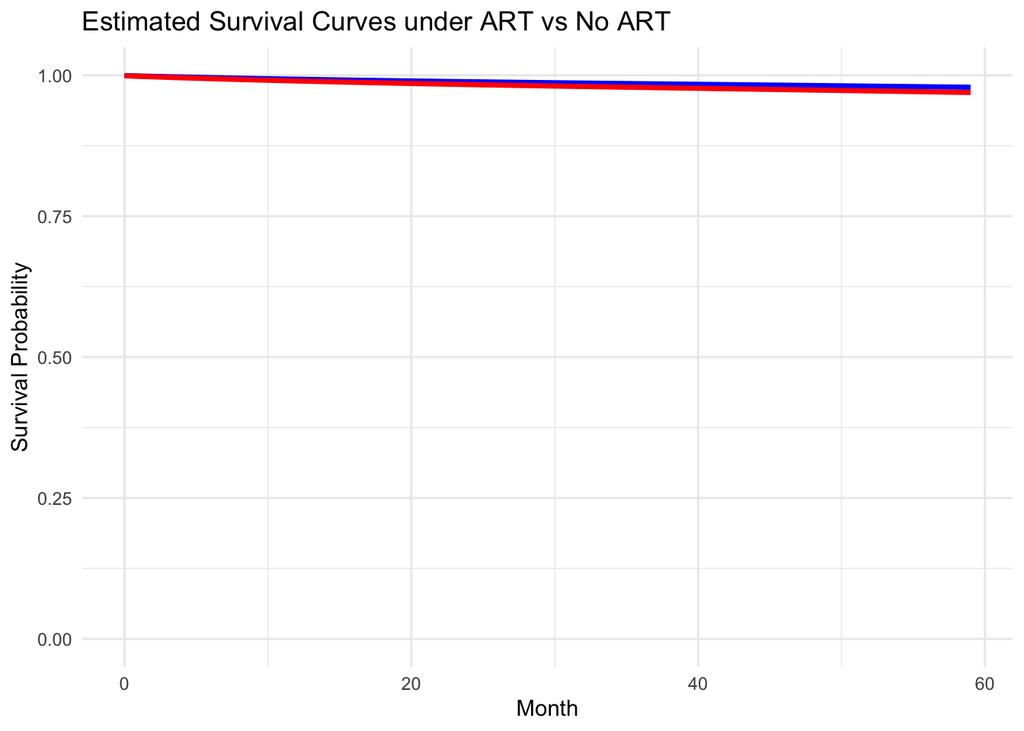

```r
predict_data <- dat
predict_data_treated <- predict_data
predict_data_treated$art <- 1

predict_data_untreated <- predict_data
predict_data_untreated$art <- 0



predict_data_treated$pred_death <- predict(modw, newdata = predict_data_treated, type = "response")
predict_data_untreated$pred_death <- predict(modw, newdata = predict_data_untreated, type = "response")



predict_data_treated$pred_surv <- 1 - predict_data_treated$pred_death
predict_data_untreated$pred_surv <- 1 - predict_data_untreated$pred_death



library(dplyr)

surv_curve_treated <- predict_data_treated %>%
  group_by(month) %>%
  summarise(surv = mean(pred_surv)) %>%
  mutate(cum_surv = cumprod(surv))

surv_curve_untreated <- predict_data_untreated %>%
  group_by(month) %>%
  summarise(surv = mean(pred_surv)) %>%
  mutate(cum_surv = cumprod(surv))



library(ggplot2)

ggplot() +
  geom_line(data = surv_curve_treated, aes(x = month, y = cum_surv), color = "blue", size = 1.2) +
  geom_line(data = surv_curve_untreated, aes(x = month, y = cum_surv), color = "red", size = 1.2) +
  labs(title = "Estimated Survival Curves under ART vs No ART",
       x = "Month",
       y = "Survival Probability") +
  theme_minimal() +
  scale_y_continuous(limits = c(0, 1)) +
  theme(legend.position = "none")
```

**Comment:** This code generates model-based counterfactual survival curves under two sustained strategies by predicting death probabilities setting art to 1 versus 0, converting them to survival probabilities, and then taking cumulative products over time. The resulting curves visualize the estimated survival advantage under ART compared with no ART across follow-up.